# Project 2

#### Group09 - Zeju Li - 836871789

#### Group09- Zonghong Yu - 803616657

#### Group09 - Zezhen Liu - 815679653

```python
import random
from seaborn.palettes import color_palette
random.seed(1789) # use last four digits of GUID
import matplotlib.pyplot as plt
import seaborn as sns
import numpy as np
import pandas as pd
import plotly.express as px
import plotly.io as pio
from sklearn import preprocessing
from sklearn.model_selection import train_test_split
```

## Load Dataset

```python
#get data set
file_path = 'datasets/bank-additional-full.csv'
# the original dataset is seperated by ';'
bank_df = pd.read_csv(file_path,sep=";")
```

```python
bank_df.head(10) # Look at the dataset
```

|  | age | job | marital | education | default | housing | loan | contact | month | day_of_week | ... | campaign | pdays | previous | poutcome | emp.var.rate | cons.price.idx | cons.conf.idx | euribor3m | nr.employed | y |
| --- | --- | --- | --- | --- | --- | --- | --- | --- | --- | --- | --- | --- | --- | --- | --- | --- | --- | --- | --- | --- | --- |
| 0 | 56 | housemaid | married | basic.4y | no | no | no | telephone | may | mon | ... | 1 | 999 | 0 | nonexistent | 1.1 | 93.994 | -36.4 | 4.857 | 5191.0 | no |
| 1 | 57 | services | married | high.school | unknown | no | no | telephone | may | mon | ... | 1 | 999 | 0 | nonexistent | 1.1 | 93.994 | -36.4 | 4.857 | 5191.0 | no |
| 2 | 37 | services | married | high.school | no | yes | no | telephone | may | mon | ... | 1 | 999 | 0 | nonexistent | 1.1 | 93.994 | -36.4 | 4.857 | 5191.0 | no |
| 3 | 40 | admin. | married | basic.6y | no | no | no | telephone | may | mon | ... | 1 | 999 | 0 | nonexistent | 1.1 | 93.994 | -36.4 | 4.857 | 5191.0 | no |
| 4 | 56 | services | married | high.school | no | no | yes | telephone | may | mon | ... | 1 | 999 | 0 | nonexistent | 1.1 | 93.994 | -36.4 | 4.857 | 5191.0 | no |
| 5 | 45 | services | married | basic.9y | unknown | no | no | telephone | may | mon | ... | 1 | 999 | 0 | nonexistent | 1.1 | 93.994 | -36.4 | 4.857 | 5191.0 | no |
| 6 | 59 | admin. | married | professional.course | no | no | no | telephone | may | mon | ... | 1 | 999 | 0 | nonexistent | 1.1 | 93.994 | -36.4 | 4.857 | 5191.0 | no |
| 7 | 41 | blue-collar | married | unknown | unknown | no | no | telephone | may | mon | ... | 1 | 999 | 0 | nonexistent | 1.1 | 93.994 | -36.4 | 4.857 | 5191.0 | no |
| 8 | 24 | technician | single | professional.course | no | yes | no | telephone | may | mon | ... | 1 | 999 | 0 | nonexistent | 1.1 | 93.994 | -36.4 | 4.857 | 5191.0 | no |
| 9 | 25 | services | single | high.school | no | yes | no | telephone | may | mon | ... | 1 | 999 | 0 | nonexistent | 1.1 | 93.994 | -36.4 | 4.857 | 5191.0 | no |

10 rows × 21 columns

```python
# Drop the duration column because it significantly affect the result (we also mention this in the report too)
bank_df = bank_df.drop('duration', axis=1)
```

## Data Preprocessing

```python
bank_df.info() # Get the information
```

```
<class 'pandas.core.frame.DataFrame'>
RangeIndex: 41188 entries, 0 to 41187
Data columns (total 20 columns):
 #   Column          Non-Null Count  Dtype
---  ------          --------------  -----
 0   age             41188 non-null  int64
 1   job             41188 non-null  object
 2   marital         41188 non-null  object
 3   education       41188 non-null  object
 4   default         41188 non-null  object
 5   housing         41188 non-null  object
 6   loan            41188 non-null  object
 7   contact         41188 non-null  object
 8   month           41188 non-null  object
 9   day_of_week     41188 non-null  object
 10  campaign        41188 non-null  int64
 11  pdays           41188 non-null  int64
 12  previous        41188 non-null  int64
 13  poutcome        41188 non-null  object
 14  emp.var.rate    41188 non-null  float64
 15  cons.price.idx  41188 non-null  float64
 16  cons.conf.idx   41188 non-null  float64
 17  euribor3m       41188 non-null  float64
 18  nr.employed     41188 non-null  float64
 19  y               41188 non-null  object
dtypes: float64(5), int64(4), object(11)
memory usage: 6.3+ MB
```

```python
# covert target variable y to binary variable
bank_df['y'] = bank_df['y'].map({'no': 0, 'yes': 1})
```

### Describe the Data

```python
bank_df.describe() # Get the data information
```

|  | age | campaign | pdays | previous | emp.var.rate | cons.price.idx | cons.conf.idx | euribor3m | nr.employed | y |
| --- | --- | --- | --- | --- | --- | --- | --- | --- | --- | --- |
| count | 41188.00000 | 41188.000000 | 41188.000000 | 41188.000000 | 41188.000000 | 41188.000000 | 41188.000000 | 41188.000000 | 41188.000000 | 41188.000000 |
| mean | 40.02406 | 2.567593 | 962.475454 | 0.172963 | 0.081886 | 93.575664 | -40.502600 | 3.621291 | 5167.035911 | 0.112654 |
| std | 10.42125 | 2.770014 | 186.910907 | 0.494901 | 1.570960 | 0.578840 | 4.628198 | 1.734447 | 72.251528 | 0.316173 |
| min | 17.00000 | 1.000000 | 0.000000 | 0.000000 | -3.400000 | 92.201000 | -50.800000 | 0.634000 | 4963.600000 | 0.000000 |
| 25% | 32.00000 | 1.000000 | 999.000000 | 0.000000 | -1.800000 | 93.075000 | -42.700000 | 1.344000 | 5099.100000 | 0.000000 |
| 50% | 38.00000 | 2.000000 | 999.000000 | 0.000000 | 1.100000 | 93.749000 | -41.800000 | 4.857000 | 5191.000000 | 0.000000 |
| 75% | 47.00000 | 3.000000 | 999.000000 | 0.000000 | 1.400000 | 93.994000 | -36.400000 | 4.961000 | 5228.100000 | 0.000000 |
| max | 98.00000 | 56.000000 | 999.000000 | 7.000000 | 1.400000 | 94.767000 | -26.900000 | 5.045000 | 5228.100000 | 1.000000 |

```python
''' Prepare for preprocessing'''
# check if  there exist unique values in categorical column
unique_values = {column: bank_df[column].unique() for column in bank_df.columns if bank_df[column].dtype == 'object'}
unique_values
```

```
{'job': array(['housemaid', 'services', 'admin.', 'blue-collar', 'technician',
        'retired', 'management', 'unemployed', 'self-employed', 'unknown',
        'entrepreneur', 'student'], dtype=object),
 'marital': array(['married', 'single', 'divorced', 'unknown'], dtype=object),
 'education': array(['basic.4y', 'high.school', 'basic.6y', 'basic.9y',
        'professional.course', 'unknown', 'university.degree',
        'illiterate'], dtype=object),
 'default': array(['no', 'unknown', 'yes'], dtype=object),
 'housing': array(['no', 'yes', 'unknown'], dtype=object),
 'loan': array(['no', 'yes', 'unknown'], dtype=object),
 'contact': array(['telephone', 'cellular'], dtype=object),
 'month': array(['may', 'jun', 'jul', 'aug', 'oct', 'nov', 'dec', 'mar', 'apr',
        'sep'], dtype=object),
 'day_of_week': array(['mon', 'tue', 'wed', 'thu', 'fri'], dtype=object),
 'poutcome': array(['nonexistent', 'failure', 'success'], dtype=object)}
```

We can see that some columns have unknown category.

```python
# lets count the number of 'unknown' values in relevant column
unknown_counts = {column: (bank_df[column] == 'unknown').sum() for column in unique_values if 'unknown' in unique_values[column]}

unknown_counts
```

```
{'job': 330,
 'marital': 80,
 'education': 1731,
 'default': 8597,
 'housing': 990,
 'loan': 990}
```

From here, we can see that the columns are imbalance. Some of the columns have much more unknown values than others do. Here we can see that these columns have many unknown counts, so to better deal with it, we will use one-hot encoding to create dummy variables for each categorical columns and drop the unknown columns.

```python
# list the colume that needed ato encode
columns_to_encode = ['job', 'marital', 'education', 'default', 'housing', 'loan', 'contact', 'month', 'day_of_week', 'poutcome']

#  dummy for on hot enchhnoding
bank_df_encoded = pd.get_dummies(bank_df, columns=columns_to_encode)
bank_df_encoded.head()
```

|  | age | campaign | pdays | previous | emp.var.rate | cons.price.idx | cons.conf.idx | euribor3m | nr.employed | y | ... | month_oct | month_sep | day_of_week_fri | day_of_week_mon | day_of_week_thu | day_of_week_tue | day_of_week_wed | poutcome_failure | poutcome_nonexistent | poutcome_success |
| --- | --- | --- | --- | --- | --- | --- | --- | --- | --- | --- | --- | --- | --- | --- | --- | --- | --- | --- | --- | --- | --- |
| 0 | 56 | 1 | 999 | 0 | 1.1 | 93.994 | -36.4 | 4.857 | 5191.0 | 0 | ... | 0 | 0 | 0 | 1 | 0 | 0 | 0 | 0 | 1 | 0 |
| 1 | 57 | 1 | 999 | 0 | 1.1 | 93.994 | -36.4 | 4.857 | 5191.0 | 0 | ... | 0 | 0 | 0 | 1 | 0 | 0 | 0 | 0 | 1 | 0 |
| 2 | 37 | 1 | 999 | 0 | 1.1 | 93.994 | -36.4 | 4.857 | 5191.0 | 0 | ... | 0 | 0 | 0 | 1 | 0 | 0 | 0 | 0 | 1 | 0 |
| 3 | 40 | 1 | 999 | 0 | 1.1 | 93.994 | -36.4 | 4.857 | 5191.0 | 0 | ... | 0 | 0 | 0 | 1 | 0 | 0 | 0 | 0 | 1 | 0 |
| 4 | 56 | 1 | 999 | 0 | 1.1 | 93.994 | -36.4 | 4.857 | 5191.0 | 0 | ... | 0 | 0 | 0 | 1 | 0 | 0 | 0 | 0 | 1 | 0 |

5 rows × 63 columns

```python
## then we drop out some redundant columns
# drop colume that have unknown
columns_to_drop = [col for col in bank_df_encoded.columns if "_unknown" in col]
bank_df_encoded = bank_df_encoded.drop(columns=columns_to_drop)
bank_df_encoded.head()
```

|  | age | campaign | pdays | previous | emp.var.rate | cons.price.idx | cons.conf.idx | euribor3m | nr.employed | y | ... | month_oct | month_sep | day_of_week_fri | day_of_week_mon | day_of_week_thu | day_of_week_tue | day_of_week_wed | poutcome_failure | poutcome_nonexistent | poutcome_success |
| --- | --- | --- | --- | --- | --- | --- | --- | --- | --- | --- | --- | --- | --- | --- | --- | --- | --- | --- | --- | --- | --- |
| 0 | 56 | 1 | 999 | 0 | 1.1 | 93.994 | -36.4 | 4.857 | 5191.0 | 0 | ... | 0 | 0 | 0 | 1 | 0 | 0 | 0 | 0 | 1 | 0 |
| 1 | 57 | 1 | 999 | 0 | 1.1 | 93.994 | -36.4 | 4.857 | 5191.0 | 0 | ... | 0 | 0 | 0 | 1 | 0 | 0 | 0 | 0 | 1 | 0 |
| 2 | 37 | 1 | 999 | 0 | 1.1 | 93.994 | -36.4 | 4.857 | 5191.0 | 0 | ... | 0 | 0 | 0 | 1 | 0 | 0 | 0 | 0 | 1 | 0 |
| 3 | 40 | 1 | 999 | 0 | 1.1 | 93.994 | -36.4 | 4.857 | 5191.0 | 0 | ... | 0 | 0 | 0 | 1 | 0 | 0 | 0 | 0 | 1 | 0 |
| 4 | 56 | 1 | 999 | 0 | 1.1 | 93.994 | -36.4 | 4.857 | 5191.0 | 0 | ... | 0 | 0 | 0 | 1 | 0 | 0 | 0 | 0 | 1 | 0 |

5 rows × 57 columns

```python
#copy the bank finished df
bank_df = bank_df_encoded.copy()
```

Now, we just one-hot encoding all the columns, and the dataframe is prepared for EDA and classification.

## Visualizations of correlation matrix

The usage of correlation matrix can help us learn the correlations among features at a glance. From here, we might perform further feature selections to prepare for the model.

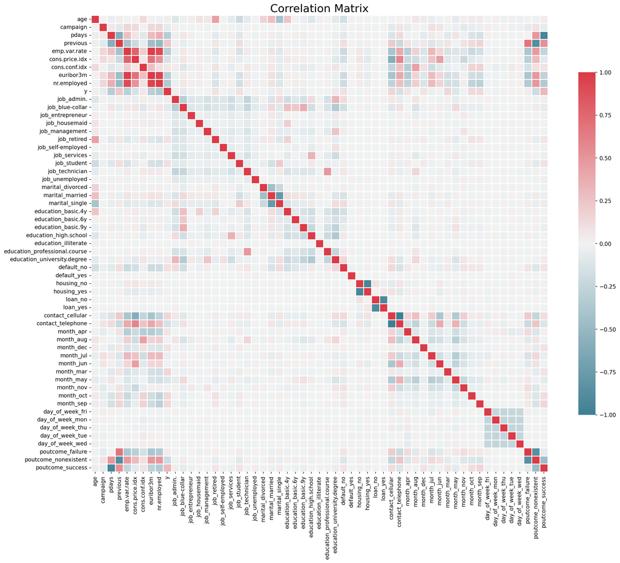

```python
# make the correlation matrix
correlation_matrix = bank_df_encoded.corr()
plt.rcParams['figure.dpi']=150
# plot it with sns diverging_palette
plt.figure(figsize=(20, 15))
cmap = sns.diverging_palette(220, 10, as_cmap=True)

# then draw the heat map
sns.heatmap(correlation_matrix, cmap=cmap, center=0, square=True, linewidths=.5, cbar_kws={"shrink": 0.75})

plt.title('Correlation Matrix', fontsize=20)
plt.show()
```

a correlation matrix is used to represent pairwise correlation coefficients between variables in the dataset to have a visualization of the correlations among features. This heatmap aims to provide us with a view of the relationships between variables. In addition, it can help the organization to have a clear and basic understanding of the relationship between features which can also let us first have a clue about which features could possibly be the cause to affect the subscription of term deposit.

## Train Test Split

```python
from sklearn.model_selection import train_test_split
from sklearn.preprocessing import StandardScaler
from sklearn.feature_selection import SelectKBest, f_classif

# set up X and y
X = bank_df.drop('y', axis=1)
y = bank_df['y']

# split the data set
X_train, X_test, y_train, y_test = train_test_split(X, y, test_size=0.2, stratify=y, random_state=1789)

# scale the data
scaler = StandardScaler()
X_train_scaled = scaler.fit_transform(X_train)
X_test_scaled = scaler.transform(X_test)

# do feature selection on the scaled training set (Do it on the training set to prevent data leakage)
# reduce features to half of the all features (top 25) to decrease the dimensionality
selector = SelectKBest(score_func=f_classif, k=25)
X_train_selected = selector.fit_transform(X_train_scaled, y_train)

# do the same transformation on the scaled test data
X_test_selected = selector.transform(X_test_scaled)

# remember the names of the selected features
selected_mask = selector.get_support()
selected_columns = X.columns[selected_mask]
print("Selected Features:", selected_columns)
```

```
Selected Features: Index(['campaign', 'pdays', 'previous', 'emp.var.rate', 'cons.price.idx',
       'cons.conf.idx', 'euribor3m', 'nr.employed', 'job_blue-collar',
       'job_retired', 'job_student', 'marital_single', 'education_basic.9y',
       'education_university.degree', 'default_no', 'contact_cellular',
       'contact_telephone', 'month_apr', 'month_dec', 'month_mar', 'month_may',
       'month_oct', 'month_sep', 'poutcome_nonexistent', 'poutcome_success'],
      dtype='object')
```

```python
# double check the distribution of the target variable 'y' in the entire dataset
y_distribution = {
    "Target Distribution": y.value_counts(normalize=True),
}

y_distribution_df = pd.DataFrame(y_distribution).transpose()
y_distribution_df
```

|  | 0 | 1 |
| --- | --- | --- |
| Target Distribution | 0.887346 | 0.112654 |

In here, we utilize the 80-20 split, which can help us provide sufficient data for training while ensuring a reliable evaluation with the test set. In the bank deposit dataset, this split with stratified sampling allows for robust model learning and a dependable estimate of the model's generalization performance, with both training and test sets containing representative samples of the minority class.

## Classification Process

```python
import pandas as pd
import matplotlib.pyplot as plt
import seaborn as sns
from sklearn.linear_model import LogisticRegression
from sklearn.neighbors import KNeighborsClassifier
from sklearn.tree import DecisionTreeClassifier
from sklearn.svm import SVC
from sklearn.naive_bayes import GaussianNB
from sklearn.ensemble import RandomForestClassifier, BaggingClassifier, GradientBoostingClassifier
import xgboost as xgb
from sklearn.metrics import accuracy_score,precision_score,recall_score
from sklearn.model_selection import cross_val_predict, cross_val_score
```

```python
'''
The following function takes in the x and y dataset and returns the boxplot.
There are a few functions: train the datasets with different models; Calculate the correponding evaluations, Get the mean accuracy and then plot it.

The reason for using the class with different functions is to keep the code clean and easy for us to check and compare the results of the models.
'''

class ClassificationRoutine:

    def __init__(self, X_train, y_train):
      # self variable
        self.X_train = X_train
        self.y_train = y_train
        # models of classifier
        self.models = {
            "Logistic Regression": LogisticRegression(max_iter=1000, random_state=1789),
            "KNN": KNeighborsClassifier(),
            "Decision Tree": DecisionTreeClassifier(random_state=1789),
            "SVC": SVC(random_state=1789),
            "Gaussian NB": GaussianNB(),
            "Random Forest": RandomForestClassifier(random_state=1789),
            "Bagging": BaggingClassifier(random_state=1789),
            "Gradient Boosting": GradientBoostingClassifier(random_state=1789),
            "XGBoost": xgb.XGBClassifier(eval_metric="logloss", random_state=1789)
        }
        self.scores = {"Accuracy": {}, "Precision": {}, "Recall": {}}
        self.cv_folds = 5

    # use cross_val_score for accuracy, precision, and recall
    def train(self):
        for name, model in self.models.items():

            self.scores["Accuracy"][name] = cross_val_score(model, self.X_train, self.y_train, scoring='accuracy', cv=self.cv_folds)
            self.scores["Precision"][name] = cross_val_score(model, self.X_train, self.y_train, scoring='precision', cv=self.cv_folds)
            self.scores["Recall"][name] = cross_val_score(model, self.X_train, self.y_train, scoring='recall', cv=self.cv_folds)

    def display_scores(self):
        # calculate the mean
        mean_scores = {
            "Accuracy": {name: np.mean(values) for name, values in self.scores["Accuracy"].items()},
            "Precision": {name: np.mean(values) for name, values in self.scores["Precision"].items()},
            "Recall": {name: np.mean(values) for name, values in self.scores["Recall"].items()}
        }
        df_scores = pd.DataFrame(mean_scores)
        return df_scores

    # plot the score using box plot
    def plot_scores(self, metric="Accuracy"):
        # construct dataframe for plotting
        df_scores = pd.DataFrame.from_dict(self.scores[metric], orient='index').reset_index()
        df_scores = df_scores.melt(id_vars=['index'], var_name='Fold', value_name=metric)

        fig, ax = plt.subplots(figsize=(15, 8))

        # box plot
        sns.boxplot(x="index", y=metric, data=df_scores, palette="Set2", width=0.5, boxprops=dict(alpha=.3), ax=ax)
        ax.set_title(f"Model {metric} Box Plot (across folds)")
        ax.set_xlabel("Model")
        ax.set_ylabel(f"{metric} Score")
        plt.xticks(rotation=45)
        ax.grid(axis='y')

        plt.tight_layout()
        plt.show()
```

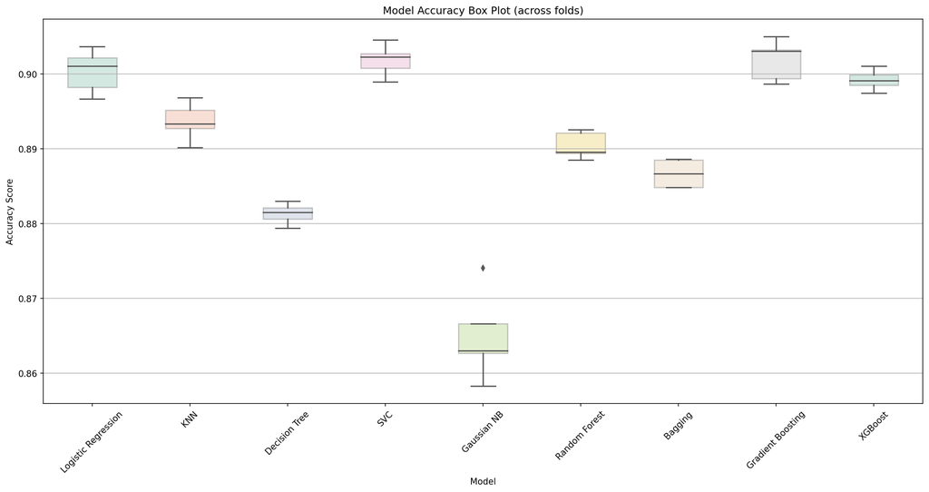

```
                     Accuracy  Precision    Recall
Logistic Regression  0.900334   0.662472  0.235195
KNN                  0.893627   0.551825  0.297955
Decision Tree        0.881305   0.458154  0.293913
SVC                  0.901851   0.660067  0.264824
Gaussian NB          0.864917   0.409378  0.446928
Random Forest        0.890410   0.522396  0.317891
Bagging              0.886677   0.495552  0.307654
Gradient Boosting    0.901851   0.671985  0.251897
XGBoost              0.899181   0.614323  0.282332
```

```python
if __name__ == "__main__":

    # make into the class object
    classifier = ClassificationRoutine(X_train_selected, y_train)
    # train the models
    classifier.train()
    # get the accuracy
    classifier.plot_scores(metric="Accuracy")
    # display our mean scores
    df_scores = classifier.display_scores()
    print(df_scores)
```

### Model Evaluation Analysis:

- **Logistic Regression**:
  - Reliable in its predictions when it identifies a positive, but has a tendency to miss many actual positives.
- **KNN**:
  - Its precision is reasonable but its recall suggests it might fail to identify a significant number of positives.
- **Decision Tree**:
  - Balanced in identifying positives but has a higher likelihood of false alarms and missed actual positives.
- **SVC**:
  - While its predictions are often correct when identifying a positive, it tends to miss many actual positives.
- **Gaussian NB**:
  - Strong at identifying many actual positives, but with a high risk of false positives.
- **Random Forest**:
  - Reasonable at predicting actual positives, but there's room for improvement in both precision and recall.
- **Bagging**:
  - Moderate in both identifying positives and avoiding false alarms, suggesting a need for tuning.
- **Gradient Boosting**:
  - Strong in accuracy and precision, but could benefit from improving its recall.
- **XGBoost**:
  - Offers a good balance between precision and recall, but there's potential for further optimization.

Considering the preliminary results, **Random Forest**, **Gradient Boosting**, **Bagging**, and **XGBoost** show promise as base models for subsequent analyses and refinements.

## Stacked Classifier Routine

Here, We want to use bagging, gradient boosting, and random forest to be base models, and xgboost to be meta model because we want to get the feature importances so that we can know whether the additional macro factors will affect our results or not. (other models can also be the meta model too, but xgboost might have better performance)

Utilizing ensemble techniques like Random Forest, Bagging, and Gradient Boosting as base models, while using XGBoost as the meta model, essentially constructs a Stacking Classifier. The idea behind stacking is to combine the outputs of several base models and use our meta-model to make a final prediction and comparison. This helps in leveraging the strengths of individual models and potentially yields better performance than any single model. In this way, we can help the organization with more promising results by identifying factors that affect the subscriptions of the clients.

```python
from sklearn.metrics import confusion_matrix
from sklearn.model_selection import KFold
from sklearn.model_selection import cross_val_score
from sklearn.model_selection import KFold
from sklearn.metrics import accuracy_score
```

```python
'''
The following function takes in the base and meta models. Then return the prediction value.
These functions aim to fit the model and train the model with cross validation.


'''
class StackedClassifier:
    def __init__(self, base_models, meta_model):
        self.base_models = base_models  # It will be a list since we use multiple base models here
        self.meta_model = meta_model
        self.predictions = None  # Initialize as None; we'll set it in fit_with_cv
        self.accuracies = []  # Store accuracies

    # do  cross validation
    def fit_with_cv(self, X, y, cv_folds=5):
        n_samples, n_models = len(X), len(self.base_models)

        # start the  matrix to store predictions from each base model for each sample
        self.predictions = np.zeros((n_samples, n_models))

        kf = KFold(n_splits=cv_folds, shuffle=True, random_state=1789)
        y = y.to_numpy() if isinstance(y, pd.Series) else y

        for train_index, val_index in kf.split(X):
            fold_X_train, fold_X_val = X[train_index], X[val_index]
            fold_y_train, fold_y_val = y[train_index], y[val_index]

            fold_predictions = np.zeros((len(val_index), n_models))

            for idx, model in enumerate(self.base_models):
                # fit base model on the training portion of the fold
                model.fit(fold_X_train, fold_y_train)

                # predict using val set
                fold_y_pred = model.predict(fold_X_val)
                fold_predictions[:, idx] = fold_y_pred
                self.predictions[val_index, idx] = fold_y_pred

            # fit meta model on this fold's predictions and compute accuracy
            self.meta_model.fit(fold_predictions, fold_y_val)
            aggregated_predictions = self.meta_model.predict(fold_predictions)
            fold_accuracy = accuracy_score(fold_y_val, aggregated_predictions)
            self.accuracies.append(fold_accuracy)

        # fit our meta model based on all previous predictions
        self.meta_model.fit(self.predictions, y)


    #  prediction function
    def predict(self, X):
        meta_input = np.column_stack([
            model.predict(X) for model in self.base_models
        ])

        # now take the meta model and get the final predictions
        final_predictions = self.meta_model.predict(meta_input)

        return final_predictions

    def get_feature_importance(self, X):
        # double check if meta-model supports feature_importances_
        if not hasattr(self.meta_model, 'feature_importances_'):
            raise ValueError("Meta-model doesn't support feature_importances_ attribute.")

        # remember importance of each base model's predictions in meta-model
        meta_importances = self.meta_model.feature_importances_

        # re start  an array to store the cumulative feature importances
        cumulative_importances = np.zeros(X.shape[1])

        # compute each base model feature importance
        for idx, model in enumerate(self.base_models):
            if hasattr(model, 'feature_importances_'):
                # Weight the feature importance of this base model by its importance in the meta-model
                weighted_importance = model.feature_importances_ * meta_importances[idx]
                cumulative_importances += weighted_importance

        # normalization for the importances so they sum up to 1
        cumulative_importances = cumulative_importances / np.sum(cumulative_importances)

        return cumulative_importances
```

```python
'''
This function does the similar process. It takes the base and meta model. Then returns confusion matrices and box plots
There are a few functions for different classifiers, stack classifiers, and plot the corresponding accuracies and confusion matrices

Here we utilize the random forest, bagging, gradient boosting as the base models, XGBoost as the meta model. The base models are selected based on the previous steps.
By using XGBoost, it can provide us with more effective comparsion and result.
'''
# run StackedClassifier and all other classifiers
class StackedClassifierRoutine:
    def __init__(self, base_models, meta_model):
        self.base_models = base_models  # This should be a list of models
        self.meta_model = meta_model
        self.classifiers = self._initialize_classifiers()
        self.stacked_clf = self._create_stacked_classifier()
        self.scores = {"Accuracy": {}}
        self.confusion_matrices = {}
        self.cv_folds = 5

    def _initialize_classifiers(self):
        return {
            "Random Forest": RandomForestClassifier(random_state=1789),
            "Bagging": BaggingClassifier(random_state=1789),
            "Gradient Boosting": GradientBoostingClassifier(random_state=1789),
            "XGBoost": xgb.XGBClassifier(eval_metric="logloss", random_state=1789)
        }

    # interfer _create_stacked_classifier
    def _create_stacked_classifier(self):
        return StackedClassifier(self.base_models, self.meta_model)

    # train those base and meta models and the stacked classifier here
    def train(self, X_train, y_train):
        for name, model in self.classifiers.items():
            # make all the model predictions
            self.scores["Accuracy"][name] = cross_val_score(model, X_train, y_train, scoring='accuracy', cv=self.cv_folds).tolist()

            # prepare the data for confusion matrix
            y_pred = cross_val_predict(model, X_train, y_train, cv=self.cv_folds)
            self.confusion_matrices[name] = confusion_matrix(y_train, y_pred)

        #  cross-validation
        self.stacked_clf.fit_with_cv(X_train, y_train, cv_folds=self.cv_folds)

        # member accuracies
        self.scores["Accuracy"]["Stacked Classifier"] = self.stacked_clf.accuracies

        y_pred_stacked = self.stacked_clf.predict(X_train)
        self.confusion_matrices["Stacked Classifier"] = confusion_matrix(y_train, y_pred_stacked)

    # plot all accuracies
    def plot_accuracies(self):
        df_scores = pd.DataFrame.from_dict(self.scores["Accuracy"], orient='index').T.melt(var_name='Model', value_name='Accuracy')

        plt.figure(figsize=(14, 8))
        sns.boxplot(data=df_scores, x="Model", y="Accuracy",  palette="Set3", width=0.5, boxprops=dict(alpha=.3))
        plt.title("Model Accuracy Box Plot (across folds)")
        plt.xticks(rotation=45)
        plt.grid(axis='y')
        plt.tight_layout()
        plt.show()
    # plot all confusion matrices
    def plot_confusion_matrices(self):
        for name, matrix in self.confusion_matrices.items():
            plt.figure(figsize=(8, 6))
            sns.heatmap(matrix, annot=True, fmt="d", cmap="Blues", cbar=False)
            plt.xlabel('Predicted Label')
            plt.ylabel('True Label')
            plt.title(f'Confusion Matrix: {name}')
            plt.show()
```

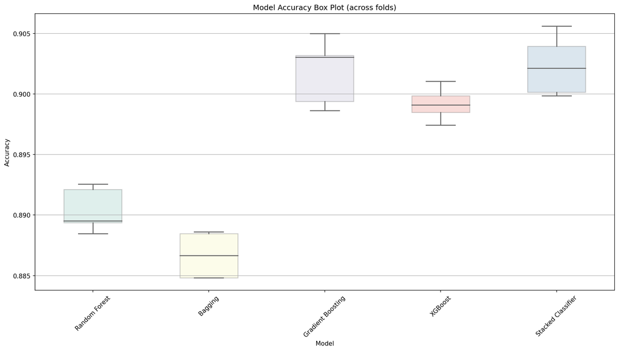

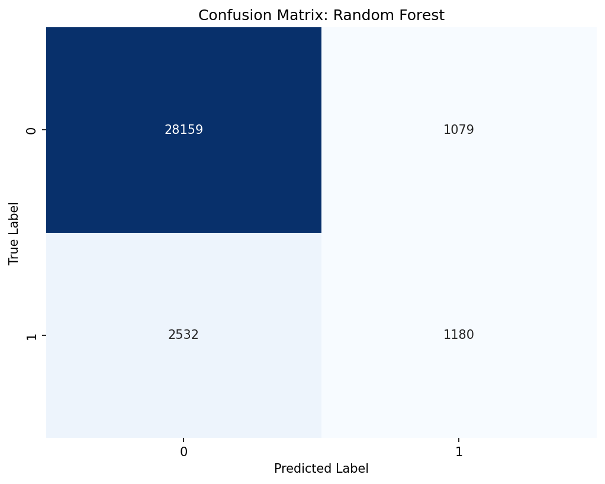

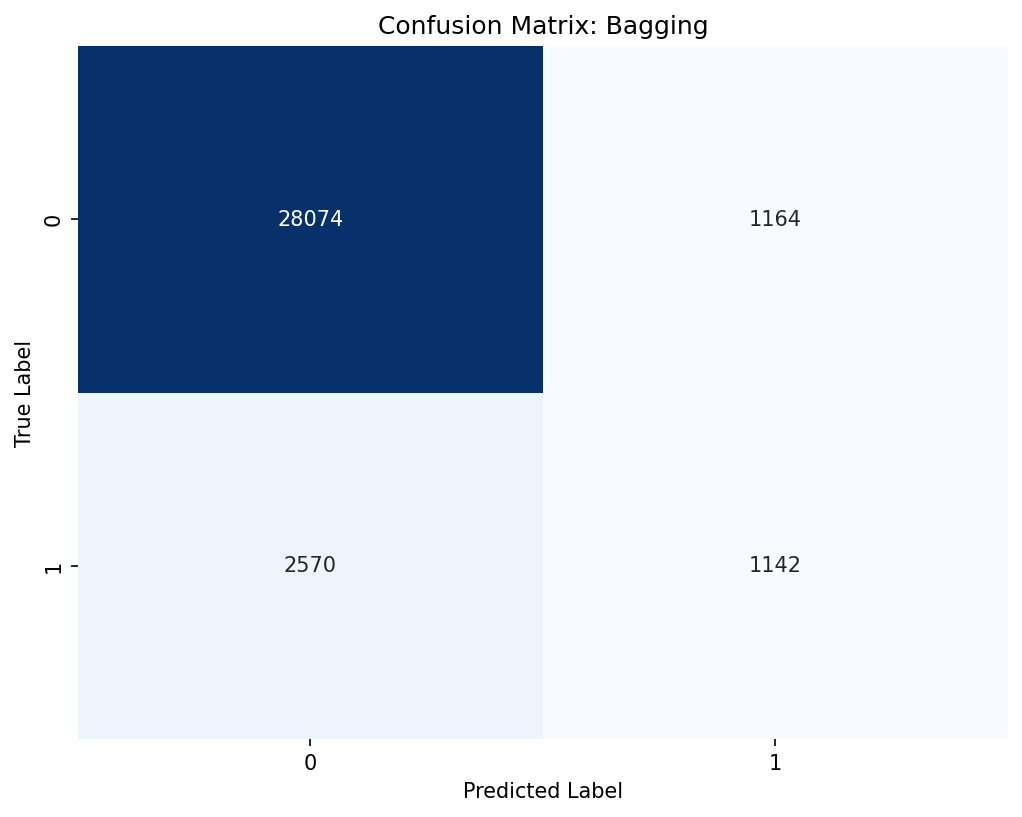

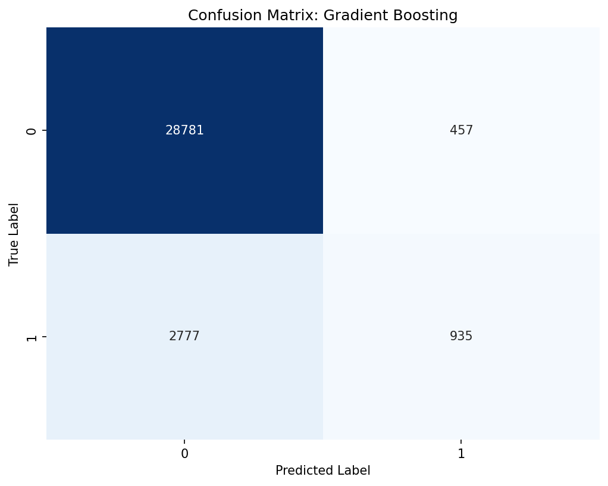

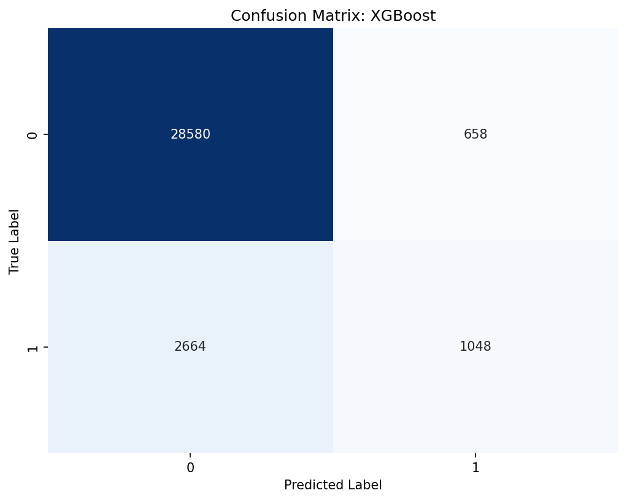

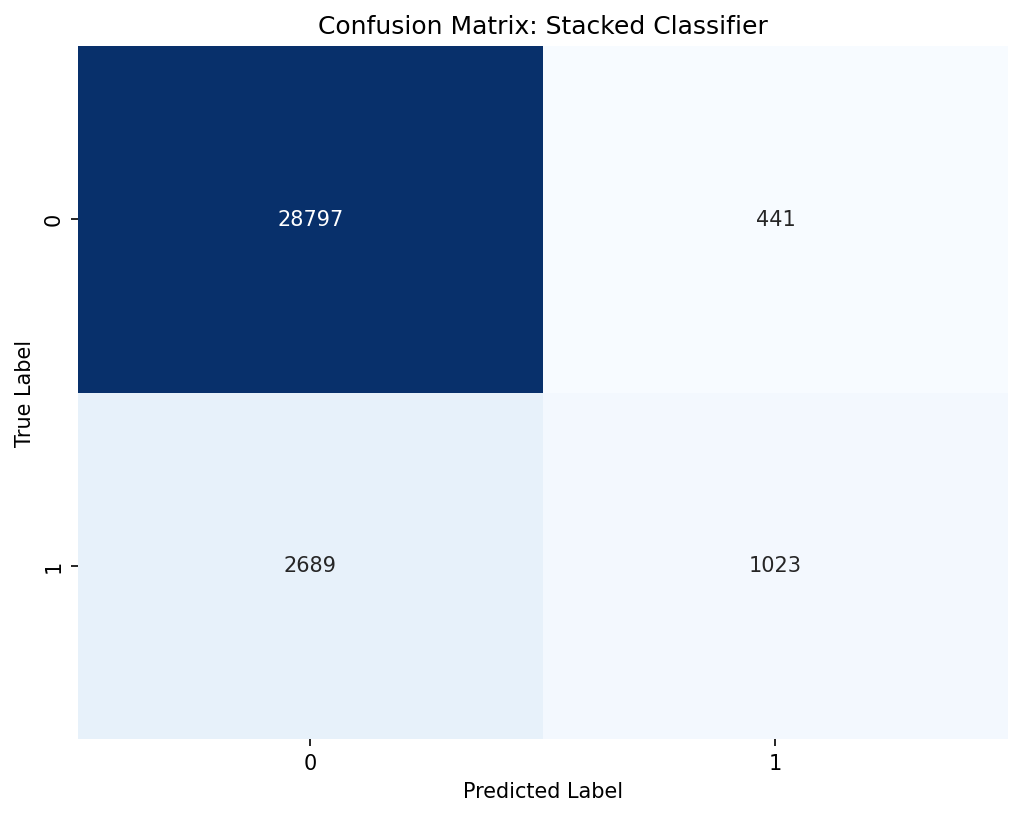

```python
if __name__ == "__main__":
    # base and meta models for the stacked classifier
    base_models = [
        BaggingClassifier(random_state=1789),
        GradientBoostingClassifier(random_state=1789),
        RandomForestClassifier(random_state=1789)
    ]
    meta_model = xgb.XGBClassifier(eval_metric="logloss", random_state=1789)

    # run the StackedClassifierRoutine
    routine = StackedClassifierRoutine(base_models, meta_model)

    # train all the models including the stacked classifier
    routine.train(X_train_selected, y_train)

    # plot accuracies
    routine.plot_accuracies()

    # plot confusion matrices
    routine.plot_confusion_matrices()
```

## Pickle Model Export

In order to make the model trackable and easy to get access, we also save the model locally.

```python
import joblib
from sklearn.metrics import confusion_matrix

# export trained model to a Pickle file
model_filename = 'stacked_model.pkl'
joblib.dump(routine.stacked_clf, model_filename)

# import trained model
loaded_model = joblib.load(model_filename)

# use imported model to predict y_test
y_pred_stacked = loaded_model.predict(X_test_selected)

# report confusion matrix
confusion = confusion_matrix(y_test, y_pred_stacked)
print("Confusion Matrix:")
print(confusion)
```

```
Confusion Matrix:
[[7172  138]
 [ 701  227]]
```

## Stacked Model Analysis

After getting the best model, we want to preform it on the scaled test data to see the results.

```
Confusion Matrix:
[[7172  138]
 [ 701  227]]
```

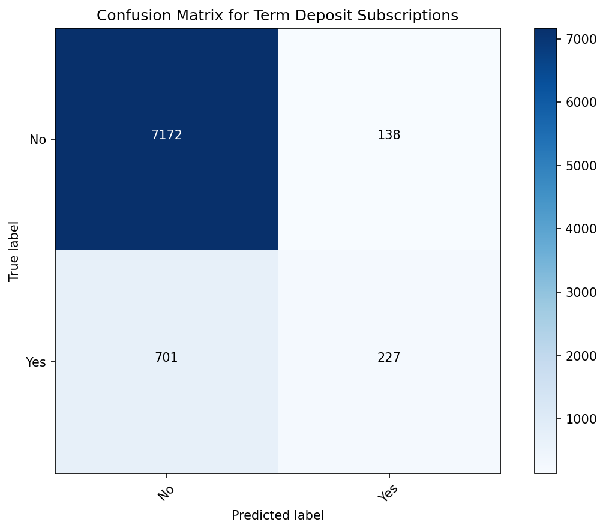

```python
import matplotlib.pyplot as plt
import numpy as np
from sklearn.metrics import confusion_matrix

plt.rcParams['figure.dpi'] = 150

# compute confusion matrix using the loaded model to predict on the scaled test data
y_pred_stacked = loaded_model.predict(X_test_selected)
confusion = confusion_matrix(y_test, y_pred_stacked)

# show text confusion matrix
print("Confusion Matrix:")
print(confusion)

# show the confusion matrix
plt.figure(figsize=(8, 6))
plt.imshow(confusion, interpolation='nearest', cmap=plt.cm.Blues)
plt.title('Confusion Matrix for Term Deposit Subscriptions')  # Adjusted title
plt.colorbar()
classes = ['No', 'Yes']  # change class names
tick_marks = np.arange(len(classes))
plt.xticks(tick_marks, classes, rotation=45)
plt.yticks(tick_marks, classes)

# add in  the text values inside the matrix cells
for i in range(len(classes)):
    for j in range(len(classes)):
        plt.text(j, i, format(confusion[i, j], 'd'),
                 horizontalalignment="center",
                 color="white" if confusion[i, j] > confusion.max() / 2 else "black")

plt.ylabel('True label')
plt.xlabel('Predicted label')
plt.tight_layout()

# display the plot
plt.show()
```

### Confusion Matrix

- **True Positives (TP)**: The model correctly identified 227 instances of customers who subscribed to the term deposit. This means it accurately predicted those who were interested in the financial product.
- **True Negatives (TN)**: The model correctly identified 7,172 instances of customers who did not subscribe to the term deposit. It accurately recognized those who were not interested.
- **False Positives (FP)**: The model mistakenly predicted 138 instances as customers who subscribed to the term deposit when they did not.
- **False Negatives (FN)**: The model missed 701 instances of customers who actually subscribed to the term deposit, but it classified them as non-subscribers. These are missed opportunities where the model failed to predict the interest.

## Feature Importance Analysis

```python
#  Get the feature importance
importances = loaded_model.get_feature_importance(X_test_selected)

# map importances to feature names for better interpretability
# use the selected_columns we name before
importance_dict = dict(zip(selected_columns, importances))
print(importance_dict)
```

[output not shown]

```python
# convert the importance dictionary to a df
importance_df = pd.DataFrame(list(importance_dict.items()), columns=['Feature', 'Importance'])

# sort the df by importance and select the top 10
top_10_importance_df = importance_df.sort_values(by='Importance', ascending=False).head(10)
print(top_10_importance_df)
```

```
             Feature  Importance
7        nr.employed    0.372877
6          euribor3m    0.183761
0           campaign    0.072687
1              pdays    0.070447
5      cons.conf.idx    0.050510
24  poutcome_success    0.048042
4     cons.price.idx    0.023976
2           previous    0.020207
21         month_oct    0.017733
11    marital_single    0.017239
```

```python
feature_mapping = {
    'nr.employed': 'No. of Employees',
    'euribor3m': 'Euribor 3M Rate',
    'campaign': 'No. of Contacts (Current Campaign)',
    'pdays': 'Days Since Last Contact',
    'cons.conf.idx': 'Consumer Confidence Index',
    'poutcome_success': 'Prev. Campaign Success',
    'cons.price.idx': 'Consumer Price Index',
    'previous': 'No. of Contacts (Previous Campaign)',
    'month_oct': 'Contacted in October',
    'marital_single': 'Single Marital Status'
}
```

```python
# map the feature names
top_10_importance_df['Feature'] = top_10_importance_df['Feature'].map(feature_mapping)
```

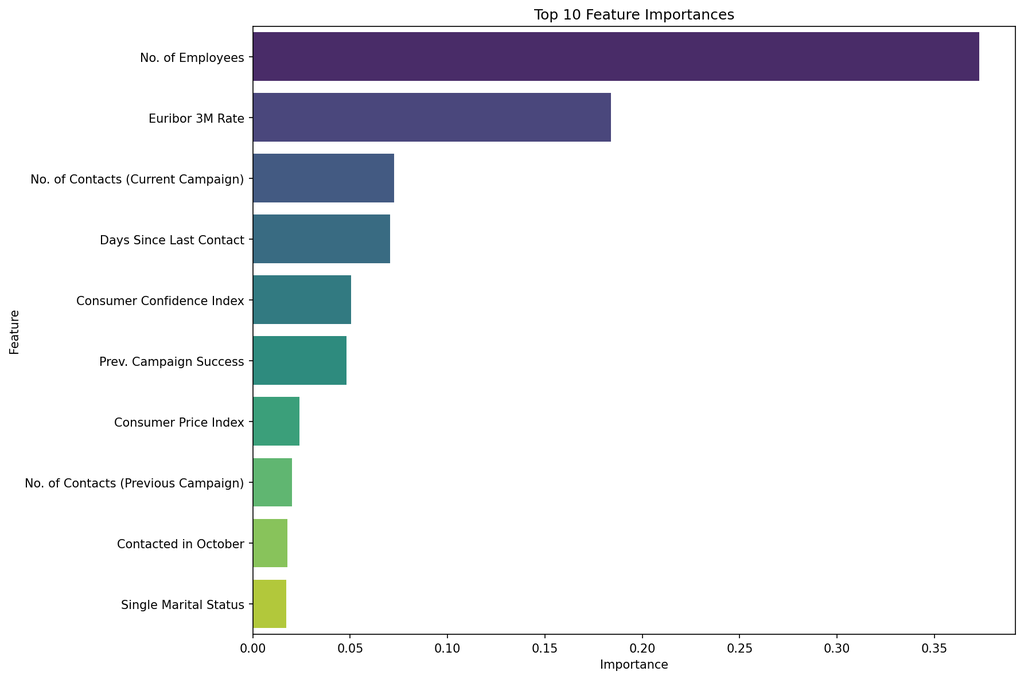

```python
# Feature Importances
plt.figure(figsize=(12, 8))
sns.barplot(data=top_10_importance_df, x='Importance', y='Feature', palette='viridis')
plt.title('Top 10 Feature Importances')
plt.tight_layout()
plt.show()
```

### Feature Importance for the Organization:

The **No. of Employees (`nr.employed`)** continues to serve as a significant quarterly economic indicator. This metric's prominence underscores the broader economic environment's role, possibly linked to the health of the banking sector or prevailing employment trends, in influencing clients' decisions to opt for a term deposit.

The **Euribor 3M Rate (`euribor3m`)**, an economic indicator, remains crucial, suggesting that shifts in this rate could impact clients' financial product decisions. Banks must be proactive and adjust their strategies in tandem with these shifts.

The **number of contacts in the current campaign (`campaign`)** plays a notable role, indicating that the frequency and timing of contact within a campaign can sway a client's decision. Efficiently orchestrating these contacts can optimize campaign success.

The **Days Since Last Contact (`pdays`)** still emphasizes the significance of well-timed interactions. Clients recently engaged might be more predisposed to offers, underlining the essence of timely follow-ups.

The **Consumer Confidence Index (`cons.conf.idx`)** offers insights into clients' economic sentiment. A positive sentiment might incline clients towards financial ventures, such as term deposits.

Interestingly, the outcome of the **Previous Campaign (`poutcome_success`)** remains an influential factor, reiterating the importance of leveraging past interactions and successes to inform current strategies.

Other attributes, including the **number of contacts before the current campaign (`previous`)** and the **Consumer Price Index (`cons.price.idx`)**, further accentuate the multifaceted nature of a client's decision-making process.

The **Contacted in October (`month_oct`)** factor sheds light on the seasonal patterns or specific marketing strategies employed in that month, suggesting its effectiveness in attracting potential clients.

Lastly, the **Single Marital Status (`marital_single`)** suggests that marital status, particularly being single, might play a role in a client's inclination towards term deposits, perhaps due to different financial commitments or future planning considerations.

**In summary**, macroeconomic factors, such as the number of employees, exert a pronounced influence on the results. Incorporating such factors into the dataset can enhance predictive accuracy, providing a more holistic understanding of clients' decision-making dynamics.